# Supermarket sales Data set

The purpose of the data set is to view the sales and to record sales transactions in Diffrent supermarkets

- Invoice id:-Computer generated sales slip invoice identification number
- Branch:-Branch of supercenter (3 branches are available identified by A, B and C)
- City:-Location of supermarkets
- Customer type:-Type of customers, recorded by Members for customers using member card and Normal for without member card
- Gender:-Gender type of customer
- Product line:-General item categorization groups
- unit price:-Price of each product in $
- Quantity:-Number of products purchased by customer
- Tax 5%:-5% tax fee for customer buying
- Total:-Total price including tax
- Date:-Date of purchase
- Time:-Purchase time
- Payment:-Payment used by customer for purchase
- Cogs:-Cost of goods sold or total price without tax
- In upcomming lines Revenue is mean by Total price
- gross margin percentage:-represents the percentage of revenue that exceeds the cost of goods sold (COGS) (gross margin =(Gross Income/Revenue)×100)
- gross income:-Gross Income is the total revenue minus the cost of goods sold (COGS).
- Rating:-Customer stratification rating on their overall shopping experience (On a scale of 1 to 10)

# Importing Packages

```python
import pandas as pd
import numpy as np
import matplotlib.pyplot as plt
import plotly.express as px
import plotly.graph_objects as go
import seaborn as sns
import warnings
warnings.filterwarnings('ignore')
```

```python
sales=pd.read_csv("supermarket_sales.csv")
pd.set_option('display.max_columns', None)
sales
```

|  | Invoice ID | Branch | City | Customer type | Gender | Product line | Unit price | Quantity | Tax 5% | Total | Date | Time | Payment | cogs | gross margin percentage | gross income | Rating |
| --- | --- | --- | --- | --- | --- | --- | --- | --- | --- | --- | --- | --- | --- | --- | --- | --- | --- |
| 0 | 750-67-8428 | A | Yangon | Member | Female | Health and beauty | 74.69 | 7 | 26.1415 | 548.9715 | 1/5/2019 | 13:08 | Ewallet | 522.83 | 4.761905 | 26.1415 | 9.1 |
| 1 | 226-31-3081 | C | Naypyitaw | Normal | Female | Electronic accessories | 15.28 | 5 | 3.8200 | 80.2200 | 3/8/2019 | 10:29 | Cash | 76.40 | 4.761905 | 3.8200 | 9.6 |
| 2 | 631-41-3108 | A | Yangon | Normal | Male | Home and lifestyle | 46.33 | 7 | 16.2155 | 340.5255 | 3/3/2019 | 13:23 | Credit card | 324.31 | 4.761905 | 16.2155 | 7.4 |
| 3 | 123-19-1176 | A | Yangon | Member | Male | Health and beauty | 58.22 | 8 | 23.2880 | 489.0480 | 1/27/2019 | 20:33 | Ewallet | 465.76 | 4.761905 | 23.2880 | 8.4 |
| 4 | 373-73-7910 | A | Yangon | Normal | Male | Sports and travel | 86.31 | 7 | 30.2085 | 634.3785 | 2/8/2019 | 10:37 | Ewallet | 604.17 | 4.761905 | 30.2085 | 5.3 |
| ... | ... | ... | ... | ... | ... | ... | ... | ... | ... | ... | ... | ... | ... | ... | ... | ... | ... |
| 995 | 233-67-5758 | C | Naypyitaw | Normal | Male | Health and beauty | 40.35 | 1 | 2.0175 | 42.3675 | 1/29/2019 | 13:46 | Ewallet | 40.35 | 4.761905 | 2.0175 | 6.2 |
| 996 | 303-96-2227 | B | Mandalay | Normal | Female | Home and lifestyle | 97.38 | 10 | 48.6900 | 1022.4900 | 3/2/2019 | 17:16 | Ewallet | 973.80 | 4.761905 | 48.6900 | 4.4 |
| 997 | 727-02-1313 | A | Yangon | Member | Male | Food and beverages | 31.84 | 1 | 1.5920 | 33.4320 | 2/9/2019 | 13:22 | Cash | 31.84 | 4.761905 | 1.5920 | 7.7 |
| 998 | 347-56-2442 | A | Yangon | Normal | Male | Home and lifestyle | 65.82 | 1 | 3.2910 | 69.1110 | 2/22/2019 | 15:33 | Cash | 65.82 | 4.761905 | 3.2910 | 4.1 |
| 999 | 849-09-3807 | A | Yangon | Member | Female | Fashion accessories | 88.34 | 7 | 30.9190 | 649.2990 | 2/18/2019 | 13:28 | Cash | 618.38 | 4.761905 | 30.9190 | 6.6 |

1000 rows × 17 columns

# Changing Data Set column names For our Understanding

```python
sales.rename(columns={'Product line':'Products','Payment':'Payment methods'},inplace=True)
sales
```

|  | Invoice ID | Branch | City | Customer type | Gender | Products | Unit price | Quantity | Tax 5% | Total | Date | Time | Payment methods | cogs | gross margin percentage | gross income | Rating |
| --- | --- | --- | --- | --- | --- | --- | --- | --- | --- | --- | --- | --- | --- | --- | --- | --- | --- |
| 0 | 750-67-8428 | A | Yangon | Member | Female | Health and beauty | 74.69 | 7 | 26.1415 | 548.9715 | 1/5/2019 | 13:08 | Ewallet | 522.83 | 4.761905 | 26.1415 | 9.1 |
| 1 | 226-31-3081 | C | Naypyitaw | Normal | Female | Electronic accessories | 15.28 | 5 | 3.8200 | 80.2200 | 3/8/2019 | 10:29 | Cash | 76.40 | 4.761905 | 3.8200 | 9.6 |
| 2 | 631-41-3108 | A | Yangon | Normal | Male | Home and lifestyle | 46.33 | 7 | 16.2155 | 340.5255 | 3/3/2019 | 13:23 | Credit card | 324.31 | 4.761905 | 16.2155 | 7.4 |
| 3 | 123-19-1176 | A | Yangon | Member | Male | Health and beauty | 58.22 | 8 | 23.2880 | 489.0480 | 1/27/2019 | 20:33 | Ewallet | 465.76 | 4.761905 | 23.2880 | 8.4 |
| 4 | 373-73-7910 | A | Yangon | Normal | Male | Sports and travel | 86.31 | 7 | 30.2085 | 634.3785 | 2/8/2019 | 10:37 | Ewallet | 604.17 | 4.761905 | 30.2085 | 5.3 |
| ... | ... | ... | ... | ... | ... | ... | ... | ... | ... | ... | ... | ... | ... | ... | ... | ... | ... |
| 995 | 233-67-5758 | C | Naypyitaw | Normal | Male | Health and beauty | 40.35 | 1 | 2.0175 | 42.3675 | 1/29/2019 | 13:46 | Ewallet | 40.35 | 4.761905 | 2.0175 | 6.2 |
| 996 | 303-96-2227 | B | Mandalay | Normal | Female | Home and lifestyle | 97.38 | 10 | 48.6900 | 1022.4900 | 3/2/2019 | 17:16 | Ewallet | 973.80 | 4.761905 | 48.6900 | 4.4 |
| 997 | 727-02-1313 | A | Yangon | Member | Male | Food and beverages | 31.84 | 1 | 1.5920 | 33.4320 | 2/9/2019 | 13:22 | Cash | 31.84 | 4.761905 | 1.5920 | 7.7 |
| 998 | 347-56-2442 | A | Yangon | Normal | Male | Home and lifestyle | 65.82 | 1 | 3.2910 | 69.1110 | 2/22/2019 | 15:33 | Cash | 65.82 | 4.761905 | 3.2910 | 4.1 |
| 999 | 849-09-3807 | A | Yangon | Member | Female | Fashion accessories | 88.34 | 7 | 30.9190 | 649.2990 | 2/18/2019 | 13:28 | Cash | 618.38 | 4.761905 | 30.9190 | 6.6 |

1000 rows × 17 columns

```python
sales = sales.drop("Invoice ID",axis = 1)
sales
```

|  | Branch | City | Customer type | Gender | Products | Unit price | Quantity | Tax 5% | Total | Date | Time | Payment methods | cogs | gross margin percentage | gross income | Rating |
| --- | --- | --- | --- | --- | --- | --- | --- | --- | --- | --- | --- | --- | --- | --- | --- | --- |
| 0 | A | Yangon | Member | Female | Health and beauty | 74.69 | 7 | 26.1415 | 548.9715 | 1/5/2019 | 13:08 | Ewallet | 522.83 | 4.761905 | 26.1415 | 9.1 |
| 1 | C | Naypyitaw | Normal | Female | Electronic accessories | 15.28 | 5 | 3.8200 | 80.2200 | 3/8/2019 | 10:29 | Cash | 76.40 | 4.761905 | 3.8200 | 9.6 |
| 2 | A | Yangon | Normal | Male | Home and lifestyle | 46.33 | 7 | 16.2155 | 340.5255 | 3/3/2019 | 13:23 | Credit card | 324.31 | 4.761905 | 16.2155 | 7.4 |
| 3 | A | Yangon | Member | Male | Health and beauty | 58.22 | 8 | 23.2880 | 489.0480 | 1/27/2019 | 20:33 | Ewallet | 465.76 | 4.761905 | 23.2880 | 8.4 |
| 4 | A | Yangon | Normal | Male | Sports and travel | 86.31 | 7 | 30.2085 | 634.3785 | 2/8/2019 | 10:37 | Ewallet | 604.17 | 4.761905 | 30.2085 | 5.3 |
| ... | ... | ... | ... | ... | ... | ... | ... | ... | ... | ... | ... | ... | ... | ... | ... | ... |
| 995 | C | Naypyitaw | Normal | Male | Health and beauty | 40.35 | 1 | 2.0175 | 42.3675 | 1/29/2019 | 13:46 | Ewallet | 40.35 | 4.761905 | 2.0175 | 6.2 |
| 996 | B | Mandalay | Normal | Female | Home and lifestyle | 97.38 | 10 | 48.6900 | 1022.4900 | 3/2/2019 | 17:16 | Ewallet | 973.80 | 4.761905 | 48.6900 | 4.4 |
| 997 | A | Yangon | Member | Male | Food and beverages | 31.84 | 1 | 1.5920 | 33.4320 | 2/9/2019 | 13:22 | Cash | 31.84 | 4.761905 | 1.5920 | 7.7 |
| 998 | A | Yangon | Normal | Male | Home and lifestyle | 65.82 | 1 | 3.2910 | 69.1110 | 2/22/2019 | 15:33 | Cash | 65.82 | 4.761905 | 3.2910 | 4.1 |
| 999 | A | Yangon | Member | Female | Fashion accessories | 88.34 | 7 | 30.9190 | 649.2990 | 2/18/2019 | 13:28 | Cash | 618.38 | 4.761905 | 30.9190 | 6.6 |

1000 rows × 16 columns

# Initial Data Exploration:

```python
sales.info()
```

```
<class 'pandas.core.frame.DataFrame'>
RangeIndex: 1000 entries, 0 to 999
Data columns (total 16 columns):
 #   Column                   Non-Null Count  Dtype
---  ------                   --------------  -----
 0   Branch                   1000 non-null   object
 1   City                     1000 non-null   object
 2   Customer type            1000 non-null   object
 3   Gender                   1000 non-null   object
 4   Products                 1000 non-null   object
 5   Unit price               1000 non-null   float64
 6   Quantity                 1000 non-null   int64
 7   Tax 5%                   1000 non-null   float64
 8   Total                    1000 non-null   float64
 9   Date                     1000 non-null   object
 10  Time                     1000 non-null   object
 11  Payment methods          1000 non-null   object
 12  cogs                     1000 non-null   float64
 13  gross margin percentage  1000 non-null   float64
 14  gross income             1000 non-null   float64
 15  Rating                   1000 non-null   float64
dtypes: float64(7), int64(1), object(8)
memory usage: 125.1+ KB
```

```python
sales.describe()
```

[output not shown]

```python
sales.shape
```

```
(1000, 16)
```

```python
sales.isnull().sum().sum()
```

```
0
```

# Cheking for outlayers:-

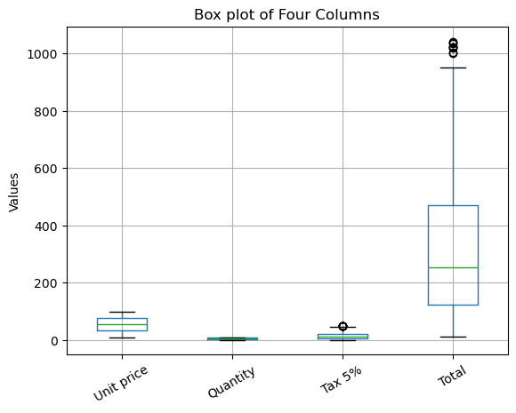

```python
import matplotlib.pyplot as plt
sales.boxplot(column=['Unit price','Quantity','Tax 5%','Total'])
plt.ylabel('Values')
plt.title('Box plot of Four Columns')
plt.xticks(rotation=30)
plt.show()
```

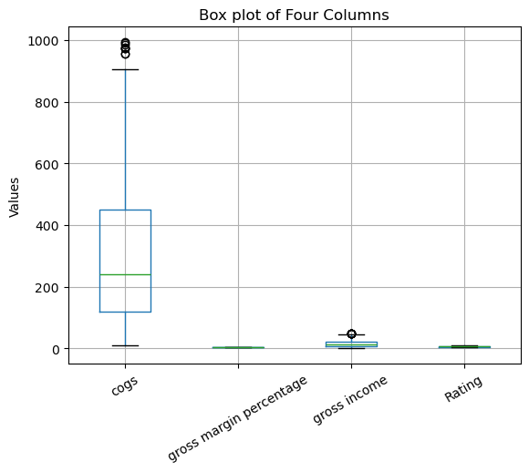

```python
import matplotlib.pyplot as plt
sales.boxplot(column=['cogs','gross margin percentage','gross income','Rating'])
plt.ylabel('Values')
plt.title('Box plot of Four Columns')
plt.xticks(rotation=30)
plt.show()
```

# Removing Outlayers:-

```python
import numpy as np
Q1=sales['Total'].quantile(0.25)
Q3=sales['Total'].quantile(0.75)
IQR=Q3-Q1

lower_bound = Q1 - 1.5 *IQR
Upper_bound = Q3 + 1.5 *IQR

print(f"Lower Bound: {lower_bound}")
print(f"Upper Bound: {Upper_bound}")

median_value = sales['Total'].median()
print(f"Median value: {median_value}")

sales['Total']=np.where((sales['Total']< lower_bound) | (sales['Total']> Upper_bound),median_value,sales['Total'])

print("Data after Replacing outliers with Median:\n",sales)
```

```
Lower Bound: -395.9694375
Upper Bound: 991.7420625
Median value: 253.848
Data after Replacing outliers with Median:
     Branch       City Customer type  Gender                Products  \
0        A     Yangon        Member  Female       Health and beauty
1        C  Naypyitaw        Normal  Female  Electronic accessories
2        A     Yangon        Normal    Male      Home and lifestyle
3        A     Yangon        Member    Male       Health and beauty
4        A     Yangon        Normal    Male       Sports and travel
..     ...        ...           ...     ...                     ...
995      C  Naypyitaw        Normal    Male       Health and beauty
996      B   Mandalay        Normal  Female      Home and lifestyle
997      A     Yangon        Member    Male      Food and beverages
998      A     Yangon        Normal    Male      Home and lifestyle
```

[output cut: 29 more lines]

```python
import numpy as np
Q1=sales['cogs'].quantile(0.25)
Q3=sales['cogs'].quantile(0.75)
IQR=Q3-Q1

lower_bound = Q1 - 1.5 *IQR
Upper_bound = Q3 + 1.5 *IQR

print(f"Lower Bound: {lower_bound}")
print(f"Upper Bound: {Upper_bound}")

median_value = sales['cogs'].median()
print(f"Median value: {median_value}")

sales['cogs']=np.where((sales['cogs']< lower_bound) | (sales['cogs']> Upper_bound),median_value,sales['cogs'])

print("Data after Replacing outliers with Median:\n",sales)
```

```
Lower Bound: -377.11375000000004
Upper Bound: 944.5162500000001
Median value: 241.76
Data after Replacing outliers with Median:
     Branch       City Customer type  Gender                Products  \
0        A     Yangon        Member  Female       Health and beauty
1        C  Naypyitaw        Normal  Female  Electronic accessories
2        A     Yangon        Normal    Male      Home and lifestyle
3        A     Yangon        Member    Male       Health and beauty
4        A     Yangon        Normal    Male       Sports and travel
..     ...        ...           ...     ...                     ...
995      C  Naypyitaw        Normal    Male       Health and beauty
996      B   Mandalay        Normal  Female      Home and lifestyle
997      A     Yangon        Member    Male      Food and beverages
998      A     Yangon        Normal    Male      Home and lifestyle
```

[output cut: 29 more lines]

```python
import numpy as np
Q1=sales['Tax 5%'].quantile(0.25)
Q3=sales['Tax 5%'].quantile(0.75)
IQR=Q3-Q1

lower_bound = Q1 - 1.5 *IQR
Upper_bound = Q3 + 1.5 *IQR

print(f"Lower Bound: {lower_bound}")
print(f"Upper Bound: {Upper_bound}")

median_value = sales['Tax 5%'].median()
print(f"Median value: {median_value}")

sales['Tax 5%']=np.where((sales['Tax 5%']< lower_bound) | (sales['Tax 5%']> Upper_bound),median_value,sales['Tax 5%'])

print("Data after Replacing outliers with Median:\n",sales)
```

```
Lower Bound: -18.855687500000002
Upper Bound: 47.2258125
Median value: 12.088000000000001
Data after Replacing outliers with Median:
     Branch       City Customer type  Gender                Products  \
0        A     Yangon        Member  Female       Health and beauty
1        C  Naypyitaw        Normal  Female  Electronic accessories
2        A     Yangon        Normal    Male      Home and lifestyle
3        A     Yangon        Member    Male       Health and beauty
4        A     Yangon        Normal    Male       Sports and travel
..     ...        ...           ...     ...                     ...
995      C  Naypyitaw        Normal    Male       Health and beauty
996      B   Mandalay        Normal  Female      Home and lifestyle
997      A     Yangon        Member    Male      Food and beverages
998      A     Yangon        Normal    Male      Home and lifestyle
```

[output cut: 29 more lines]

```python
import numpy as np
Q1=sales['gross income'].quantile(0.25)
Q3=sales['gross income'].quantile(0.75)
IQR=Q3-Q1

lower_bound = Q1 - 1.5 *IQR
Upper_bound = Q3 + 1.5 *IQR

print(f"Lower Bound: {lower_bound}")
print(f"Upper Bound: {Upper_bound}")

median_value = sales['gross income'].median()
print(f"Median value: {median_value}")

sales['gross income']=np.where((sales['gross income']< lower_bound) | (sales['gross income']> Upper_bound),median_value,sales['gross income'])

print("Data after Replacing outliers with Median:\n",sales)
```

```
Lower Bound: -18.855687500000002
Upper Bound: 47.2258125
Median value: 12.088000000000001
Data after Replacing outliers with Median:
     Branch       City Customer type  Gender                Products  \
0        A     Yangon        Member  Female       Health and beauty
1        C  Naypyitaw        Normal  Female  Electronic accessories
2        A     Yangon        Normal    Male      Home and lifestyle
3        A     Yangon        Member    Male       Health and beauty
4        A     Yangon        Normal    Male       Sports and travel
..     ...        ...           ...     ...                     ...
995      C  Naypyitaw        Normal    Male       Health and beauty
996      B   Mandalay        Normal  Female      Home and lifestyle
997      A     Yangon        Member    Male      Food and beverages
998      A     Yangon        Normal    Male      Home and lifestyle
```

[output cut: 29 more lines]

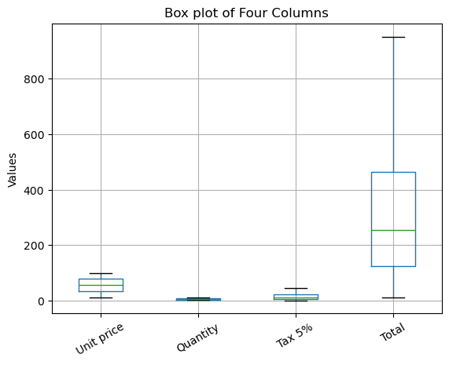

```python
import matplotlib.pyplot as plt
sales.boxplot(column=['Unit price','Quantity','Tax 5%','Total'])
plt.ylabel('Values')
plt.title('Box plot of Four Columns')
plt.xticks(rotation=30)
plt.show()
```

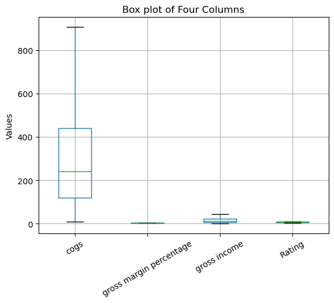

```python
import matplotlib.pyplot as plt
sales.boxplot(column=['cogs','gross margin percentage','gross income','Rating'])
plt.ylabel('Values')
plt.title('Box plot of Four Columns')
plt.xticks(rotation=30)
plt.show()
```

# Exploratory Data Analysis (EDA):

# Bar chart

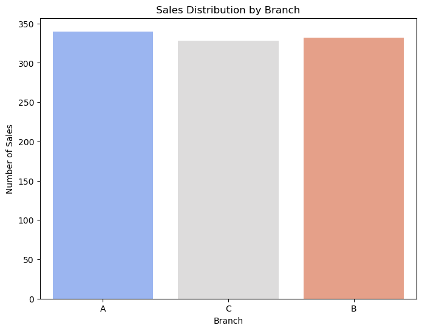

```python
plt.figure(figsize=(8, 6))
sns.countplot(x='Branch', data=sales, palette='coolwarm')
plt.title('Sales Distribution by Branch')
plt.xlabel('Branch')
plt.ylabel('Number of Sales')
plt.show()
```

From the following infrences:-

- A Branch has highest sales compared to C and B

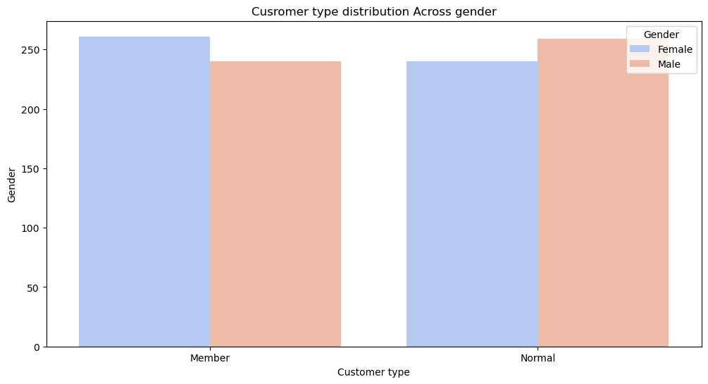

```python
plt.figure(figsize = (12 , 6))
sns.countplot(x = 'Customer type' , hue = 'Gender' , data = sales , palette = 'coolwarm')
plt.title("Cusromer type distribution Across gender")
plt.xlabel("Customer type")
plt.ylabel("Gender")
plt.xticks()
plt.show()
```

From the following Bar graph i Infer that:-

- In Member card users Males have less customers compared to Female
- Whereas while seeing to Normal type customers Male Have High customers compared to Females

[figure not shown]

```python
plt.style.use("default")
plt.figure(figsize=(5,5))
sns.barplot(x="Gender", y="Rating", data=sales, palette='coolwarm')
plt.title("Rating vs Gender",fontsize=15)
plt.xlabel("Rating")
plt.ylabel("Gender")
plt.show()
```

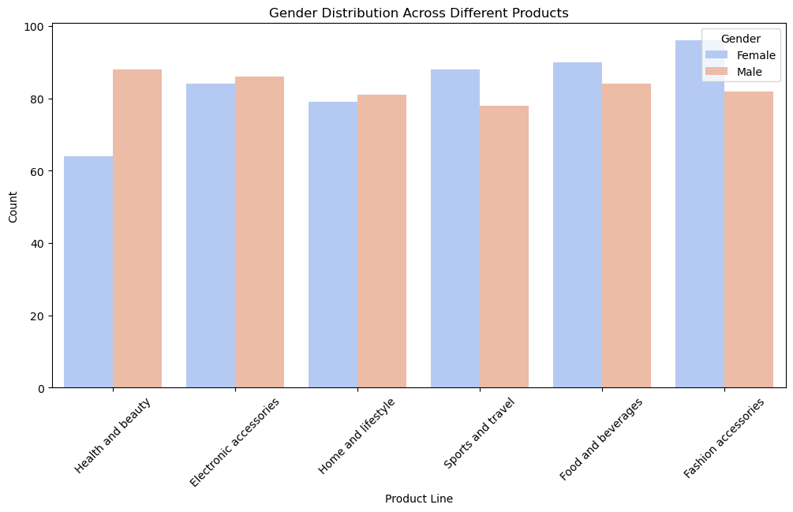

```python
plt.figure(figsize=(12, 6))
sns.countplot(x='Products', hue='Gender', data=sales, palette='coolwarm')
plt.title('Gender Distribution Across Different Products')
plt.xlabel('Product Line')
plt.ylabel('Count')
plt.xticks(rotation=45)
plt.show()
```

Certain product lines like "Fashion accessories" is more popular among female customers, while male customers are more inclined toward "Health and beauty" and "Electronic accessories"

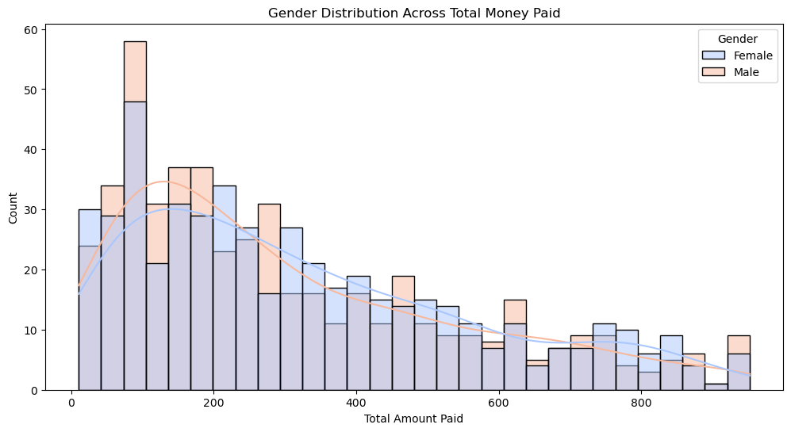

```python
plt.figure(figsize=(12, 6))
sns.histplot(data=sales, x='Total', hue='Gender', kde=True, palette='coolwarm', bins=30)
plt.title('Gender Distribution Across Total Money Paid')
plt.xlabel('Total Amount Paid')
plt.ylabel('Count')
plt.show()
```

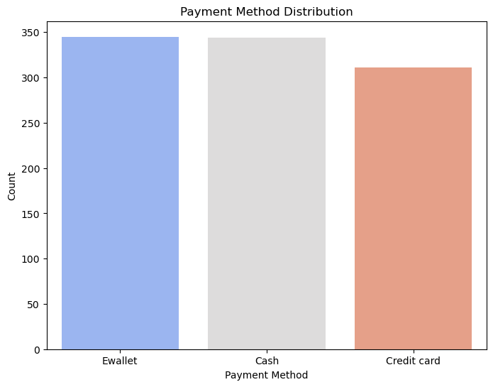

```python
plt.figure(figsize=(8, 6))
sns.countplot(x='Payment methods', data=sales, palette='coolwarm')
plt.title('Payment Method Distribution')
plt.xlabel('Payment Method')
plt.ylabel('Count')
plt.show()
```

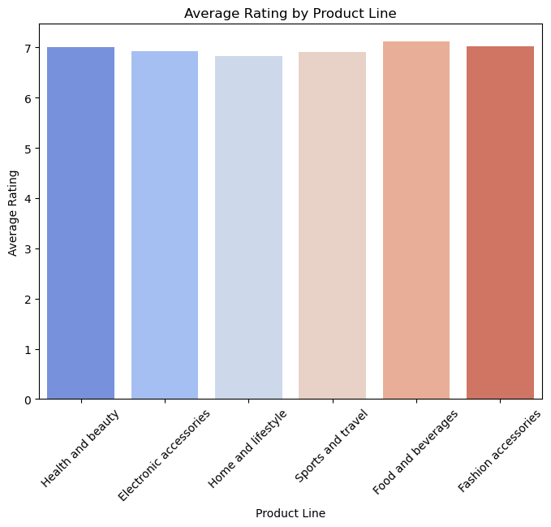

```python
plt.figure(figsize=(8, 6))
sns.barplot(x='Products', y='Rating', data=sales, palette='coolwarm', ci=None)
plt.title('Average Rating by Product Line')
plt.xlabel('Product Line')
plt.ylabel('Average Rating')
plt.xticks(rotation=45)
plt.show()
```

[figure not shown]

```python
plt.figure(figsize=(10, 6))
sns.barplot(x='City', y='Total', data=sales, estimator=sum, palette='coolwarm', ci=None)
plt.title('Total Sales by City')
plt.xlabel('City')
plt.ylabel('Total Sales')
plt.show()
```

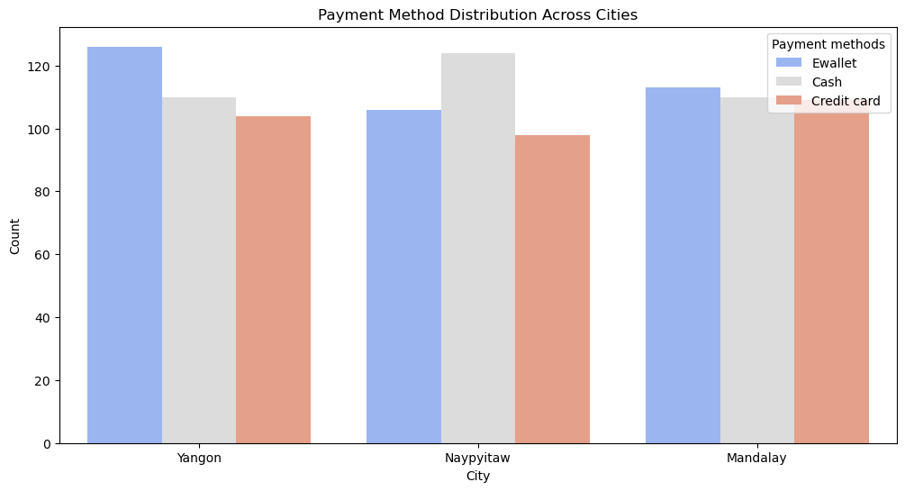

```python
plt.figure(figsize=(12, 6))
sns.countplot(x='City', hue='Payment methods', data=sales, palette='coolwarm')
plt.title('Payment Method Distribution Across Cities')
plt.xlabel('City')
plt.ylabel('Count')
plt.show()
```

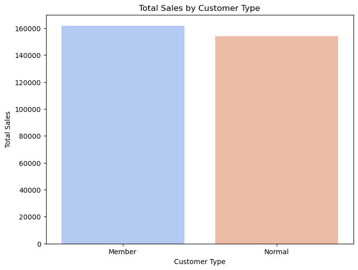

```python
plt.figure(figsize=(8, 6))
sns.barplot(x='Customer type', y='Total', data=sales, estimator=sum, palette='coolwarm', ci=None)
plt.title('Total Sales by Customer Type')
plt.xlabel('Customer Type')
plt.ylabel('Total Sales')
plt.show()
```

[figure not shown]

```python
sns.histplot(sales['Total'], bins=25, kde=True)

# Add labels and title for clarity
plt.title('Distribution of Total Sales')
plt.xlabel('Total Sales')
plt.ylabel('count')

# Show the plot
plt.show()
```

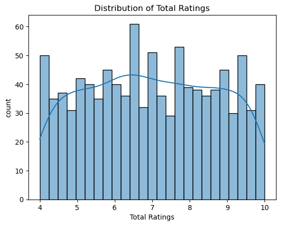

```python
sns.histplot(sales['Rating'], bins=25, kde=True)

# Add labels and title for clarity
plt.title('Distribution of Total Ratings')
plt.xlabel('Total Ratings')
plt.ylabel('count')

# Show the plot
plt.show()
```

# Line Chart

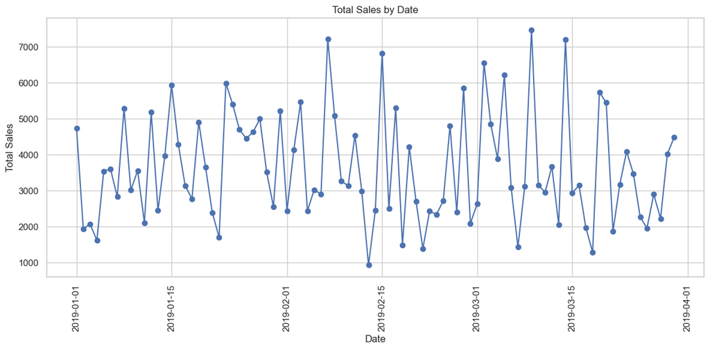

```python
import pandas as pd
import matplotlib.pyplot as plt
sales = pd.read_csv('supermarket_sales.csv')
sales['Date'] = pd.to_datetime(sales['Date'], format='%m/%d/%Y')
daily_sales = sales.groupby('Date')['Total'].sum()
plt.figure(figsize=(12, 6))
plt.plot(daily_sales.index, daily_sales.values, marker='o', linestyle='-')
plt.title('Total Sales by Date')
plt.xlabel('Date')
plt.ylabel('Total Sales')
plt.xticks(rotation=90)
plt.grid(True)
plt.tight_layout()
plt.show()
```

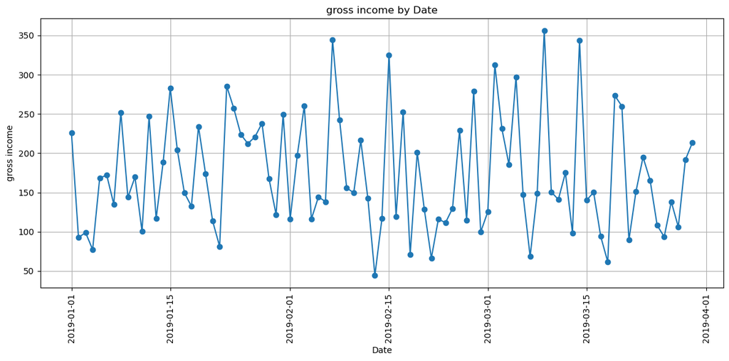

```python
import pandas as pd
import matplotlib.pyplot as plt
sales = pd.read_csv('supermarket_sales.csv')
sales['Date'] = pd.to_datetime(sales['Date'], format='%m/%d/%Y')
daily_sales = sales.groupby('Date')['gross income'].sum()
plt.figure(figsize=(12, 6))
plt.plot(daily_sales.index, daily_sales.values, marker='o', linestyle='-')
plt.title('gross income by Date')
plt.xlabel('Date')
plt.ylabel('gross income')
plt.xticks(rotation=90)
plt.grid(True)
plt.tight_layout()
plt.show()
```

# Violinplot

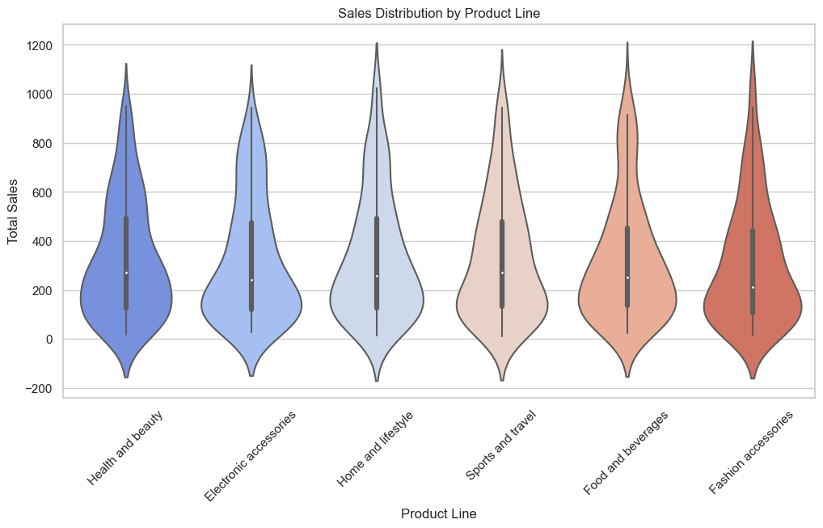

```python
plt.figure(figsize=(12, 6))
sns.violinplot(x='Product line', y='Total', data=sales, palette='coolwarm')
plt.title('Sales Distribution by Product Line')
plt.xlabel('Product Line')
plt.ylabel('Total Sales')
plt.xticks(rotation=45)
plt.show()
```

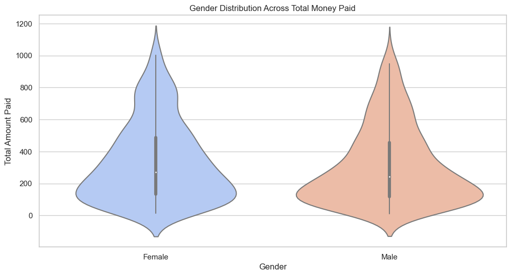

```python
plt.figure(figsize=(12, 6))
sns.violinplot(x='Gender', y='Total', data=sales, palette='coolwarm')
plt.title('Gender Distribution Across Total Money Paid')
plt.xlabel('Gender')
plt.ylabel('Total Amount Paid')
plt.show()
```

# Pie chart

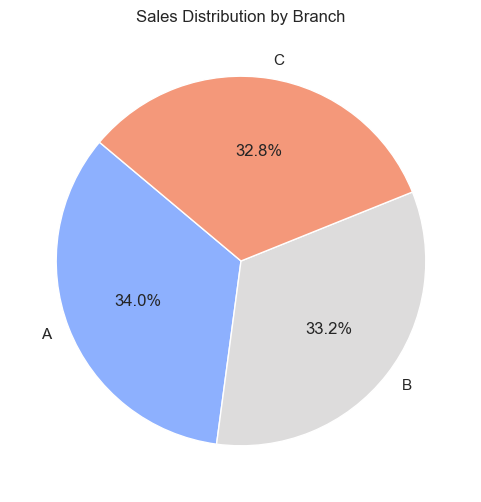

```python
branch_sales = sales['Branch'].value_counts()

# Plot a pie chart
plt.figure(figsize=(6, 6))
plt.pie(branch_sales, labels=branch_sales.index, autopct='%1.1f%%', startangle=140, colors=sns.color_palette('coolwarm', len(branch_sales)))
plt.title('Sales Distribution by Branch')
plt.show()
```

[figure not shown]

```python
plt.figure(figsize=(6, 6))
plt.pie(sales["Gender"].value_counts() , labels=sales["Gender"].value_counts().index, autopct='%1.1f%%', startangle=140, colors=sns.color_palette('coolwarm', len(sales["Gender"].value_counts())))
plt.title('Sales Distribution by Branch')
plt.show()
```

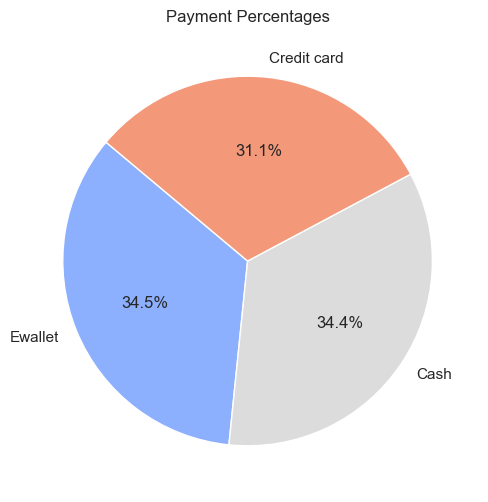

```python
plt.figure(figsize=(6, 6))
plt.pie(sales['Payment'].value_counts(), labels=sales['Payment'].value_counts().index, autopct='%1.1f%%', startangle=140, colors=sns.color_palette('coolwarm', len(sales['Payment'].value_counts())))
plt.title('Payment Percentages')
plt.show()
```

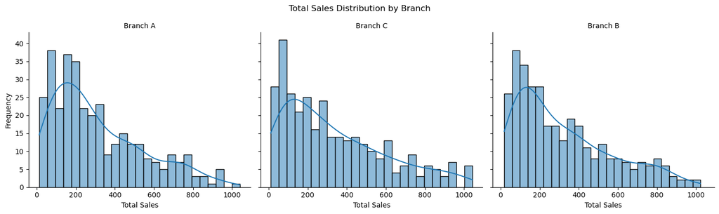

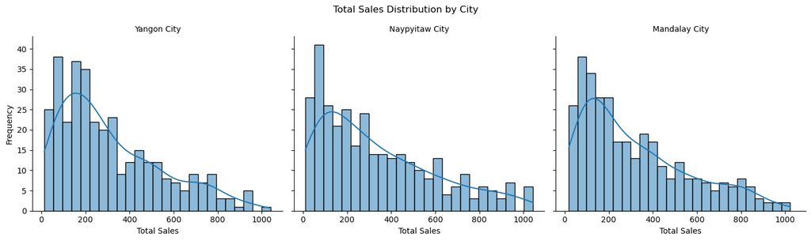

```python
import seaborn as sns
import matplotlib.pyplot as plt

# Assuming 'sales' is your DataFrame and you're using 'Branch' and 'City' as categorical variables
# Plot Total distribution for each Branch
g = sns.FacetGrid(sales, col='Branch', height=4, aspect=1.2)
g.map(sns.histplot, 'Total', bins=25, kde=True)
g.set_axis_labels('Total Sales', 'Frequency')
g.set_titles(col_template="Branch {col_name}")
g.fig.suptitle('Total Sales Distribution by Branch', y=1.05)
plt.show()

# Plot Total distribution for each City
g = sns.FacetGrid(sales, col='City', height=4, aspect=1.2, col_wrap=3)
g.map(sns.histplot, 'Total', bins=25, kde=True)
g.set_axis_labels('Total Sales', 'Frequency')
g.set_titles(col_template="{col_name} City")
g.fig.suptitle('Total Sales Distribution by City', y=1.05)
plt.show()
```

```python
histogram = px.histogram(
    sales,
    x='Unit price',
    nbins=20,
    title='Unit price Distribution',
)

# Update layout for black background
histogram.update_layout(
    paper_bgcolor='white',  # Background color of the whole figure
    plot_bgcolor='white',   # Background color of the plotting area
    title_font_color='black',  # Title color
    xaxis_title_font_color='black',  # X-axis title color
    yaxis_title_font_color='black',  # Y-axis title color
    xaxis_tickfont_color='black',  # X-axis tick labels color
    yaxis_tickfont_color='black'   # Y-axis tick labels color
)

# Show the plot
histogram.show()
```

[interactive chart not shown]

```python
histogram = px.histogram(
    sales,
    x='Quantity',
    nbins=20,
    title='Quantity Distribution',
)

# Update layout for black background
histogram.update_layout(
    paper_bgcolor='black',  # Background color of the whole figure
    plot_bgcolor='black',   # Background color of the plotting area
    title_font_color='white',  # Title color
    xaxis_title_font_color='white',  # X-axis title color
    yaxis_title_font_color='white',  # Y-axis title color
    xaxis_tickfont_color='white',  # X-axis tick labels color
    yaxis_tickfont_color='white'   # Y-axis tick labels color
)

# Show the plot
histogram.show()
```

[interactive chart not shown]

```python
histogram = px.histogram(
    sales,
    x='Tax 5%',
    nbins=20,
    title='Tax 5% Distribution',
)

# Update layout for black background
histogram.update_layout(
    paper_bgcolor='white',  # Background color of the whole figure
    plot_bgcolor='white',   # Background color of the plotting area
    title_font_color='black',  # Title color
    xaxis_title_font_color='black',  # X-axis title color
    yaxis_title_font_color='black',  # Y-axis title color
    xaxis_tickfont_color='black',  # X-axis tick labels color
    yaxis_tickfont_color='black'   # Y-axis tick labels color
)

# Show the plot
histogram.show()
```

[interactive chart not shown]

```python
sales.describe()
```

|  | Unit price | Quantity | Tax 5% | Total | Date | cogs | gross margin percentage | gross income | Rating |
| --- | --- | --- | --- | --- | --- | --- | --- | --- | --- |
| count | 1000.000000 | 1000.000000 | 1000.000000 | 1000.000000 | 1000 | 1000.00000 | 1.000000e+03 | 1000.000000 | 1000.00000 |
| mean | 55.672130 | 5.510000 | 15.379369 | 322.966749 | 2019-02-14 00:05:45.600000 | 307.58738 | 4.761905e+00 | 15.379369 | 6.97270 |
| min | 10.080000 | 1.000000 | 0.508500 | 10.678500 | 2019-01-01 00:00:00 | 10.17000 | 4.761905e+00 | 0.508500 | 4.00000 |
| 25% | 32.875000 | 3.000000 | 5.924875 | 124.422375 | 2019-01-24 00:00:00 | 118.49750 | 4.761905e+00 | 5.924875 | 5.50000 |
| 50% | 55.230000 | 5.000000 | 12.088000 | 253.848000 | 2019-02-13 00:00:00 | 241.76000 | 4.761905e+00 | 12.088000 | 7.00000 |
| 75% | 77.935000 | 8.000000 | 22.445250 | 471.350250 | 2019-03-08 00:00:00 | 448.90500 | 4.761905e+00 | 22.445250 | 8.50000 |
| max | 99.960000 | 10.000000 | 49.650000 | 1042.650000 | 2019-03-30 00:00:00 | 993.00000 | 4.761905e+00 | 49.650000 | 10.00000 |
| std | 26.494628 | 2.923431 | 11.708825 | 245.885335 | NaN | 234.17651 | 6.131498e-14 | 11.708825 | 1.71858 |

```python
histogram = px.histogram(
    sales,
    x='Total',
    nbins=20,
    title='Total Distribution',
)

# Update layout for black background
histogram.update_layout(
    paper_bgcolor='black',  # Background color of the whole figure
    plot_bgcolor='black',   # Background color of the plotting area
    title_font_color='white',  # Title color
    xaxis_title_font_color='white',  # X-axis title color
    yaxis_title_font_color='white',  # Y-axis title color
    xaxis_tickfont_color='white',  # X-axis tick labels color
    yaxis_tickfont_color='white'   # Y-axis tick labels color
)

# Show the plot
histogram.show()
```

[interactive chart not shown]

```python
histogram = px.histogram(
    sales,
    x='cogs',
    nbins=20,
    title='cogs Distribution',
)

# Update layout for black background
histogram.update_layout(
    paper_bgcolor='white',  # Background color of the whole figure black
    plot_bgcolor='white',   # Background color of the plotting area
    title_font_color='black',  # Title color
    xaxis_title_font_color='black',  # X-axis title color
    yaxis_title_font_color='black',  # Y-axis title color
    xaxis_tickfont_color='black',  # X-axis tick labels color
    yaxis_tickfont_color='black'   # Y-axis tick labels color
)

# Show the plot
histogram.show()
```

[interactive chart not shown]

```python
histogram = px.histogram(
    sales,
    x='gross income',
    nbins=20,
    title='gross income Distribution',
)

# Update layout for black background
histogram.update_layout(
    paper_bgcolor='black',  # Background color of the whole figure
    plot_bgcolor='black',   # Background color of the plotting area
    title_font_color='white',  # Title color
    xaxis_title_font_color='white',  # X-axis title color
    yaxis_title_font_color='white',  # Y-axis title color
    xaxis_tickfont_color='white',  # X-axis tick labels color
    yaxis_tickfont_color='white'   # Y-axis tick labels color
)

# Show the plot
histogram.show()
```

[interactive chart not shown]

```python
histogram = px.histogram(
    sales,
    x='Rating',
    nbins=20,
    title='Rating Distribution',
)

# Update layout for black background
histogram.update_layout(
    paper_bgcolor='white',  # Background color of the whole figure
    plot_bgcolor='white',   # Background color of the plotting area
    title_font_color='black',  # Title color
    xaxis_title_font_color='black',  # X-axis title color
    yaxis_title_font_color='black',  # Y-axis title color
    xaxis_tickfont_color='black',  # X-axis tick labels color
    yaxis_tickfont_color='black'   # Y-axis tick labels color
)

# Show the plot
histogram.show()
```

[interactive chart not shown]

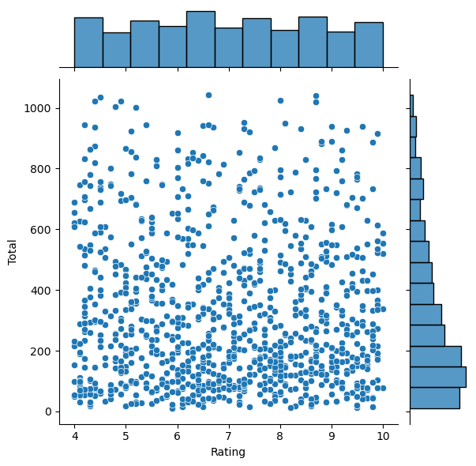

```python
sns.jointplot(x='Rating', y= 'Total', data=sales)
```

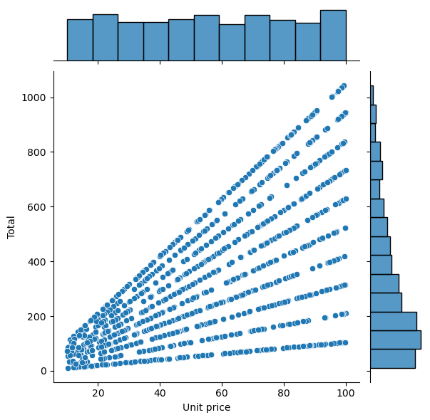

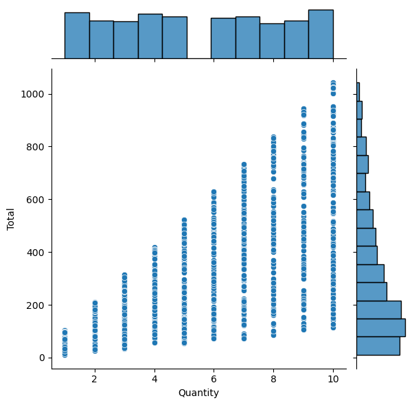

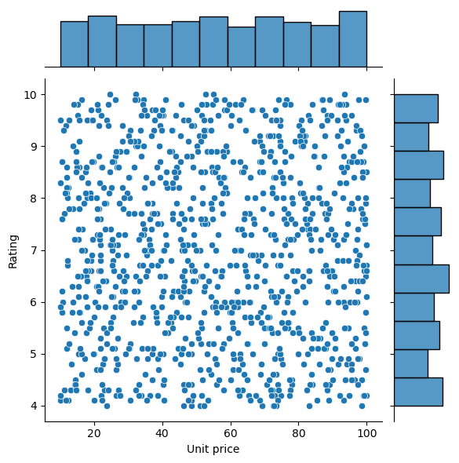

```python
import seaborn as sns
import pandas as pd

# Load the dataset
sales = pd.read_csv("supermarket_sales.csv", encoding='ISO-8859-1')

# Joint plot for Unit price vs. Total
sns.jointplot(x='Unit price', y='Total', data=sales, kind='scatter')

# Joint plot for Quantity vs. Total
sns.jointplot(x='Quantity', y='Total', data=sales, kind='scatter')

# Joint plot for Unit price vs. Rating
sns.jointplot(x='Unit price', y='Rating', data=sales, kind='scatter')
```

# Pairplot

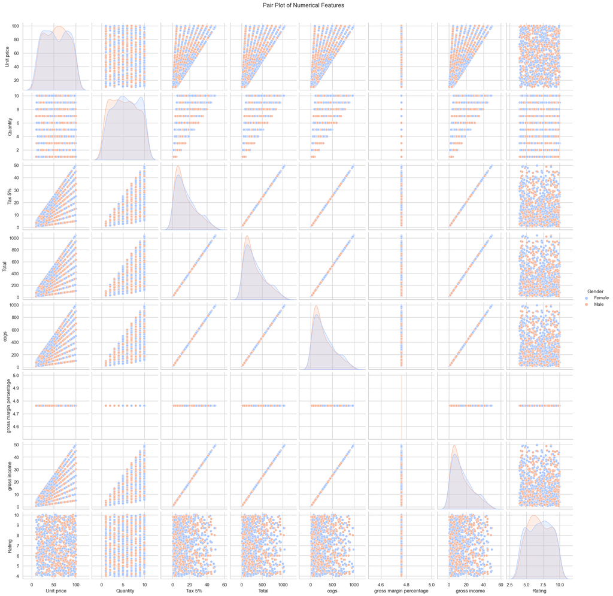

```python
sns.pairplot(sales, hue='Gender', palette='coolwarm')
plt.suptitle('Pair Plot of Numerical Features', y=1.02)
plt.show()
```

# Heatmap

[figure not shown]

```python
import seaborn as sns
import matplotlib.pyplot as plt
selected_columns=['Unit price','Quantity','Tax 5%','Total','cogs','gross income','Rating'] #'gross margin percentage',
df_selected=sales[selected_columns]
correlation_matrix=df_selected.corr()
plt.figure(figsize=(18,10))
sns.heatmap(correlation_matrix,annot=True,cmap='coolwarm',linewidth=4,fmt=".2f")
plt.title('Heatmap of Six columns')
plt.show()
```

```python
sales
```

|  | Branch | City | Customer type | Gender | Products | Unit price | Quantity | Tax 5% | Total | Date | Time | Payment methods | cogs | gross margin percentage | gross income | Rating |
| --- | --- | --- | --- | --- | --- | --- | --- | --- | --- | --- | --- | --- | --- | --- | --- | --- |
| 0 | A | Yangon | Member | Female | Health and beauty | 74.69 | 7 | 26.1415 | 548.9715 | 1/5/2019 | 13:08 | Ewallet | 522.83 | 4.761905 | 26.1415 | 9.1 |
| 1 | C | Naypyitaw | Normal | Female | Electronic accessories | 15.28 | 5 | 3.8200 | 80.2200 | 3/8/2019 | 10:29 | Cash | 76.40 | 4.761905 | 3.8200 | 9.6 |
| 2 | A | Yangon | Normal | Male | Home and lifestyle | 46.33 | 7 | 16.2155 | 340.5255 | 3/3/2019 | 13:23 | Credit card | 324.31 | 4.761905 | 16.2155 | 7.4 |
| 3 | A | Yangon | Member | Male | Health and beauty | 58.22 | 8 | 23.2880 | 489.0480 | 1/27/2019 | 20:33 | Ewallet | 465.76 | 4.761905 | 23.2880 | 8.4 |
| 4 | A | Yangon | Normal | Male | Sports and travel | 86.31 | 7 | 30.2085 | 634.3785 | 2/8/2019 | 10:37 | Ewallet | 604.17 | 4.761905 | 30.2085 | 5.3 |
| ... | ... | ... | ... | ... | ... | ... | ... | ... | ... | ... | ... | ... | ... | ... | ... | ... |
| 995 | C | Naypyitaw | Normal | Male | Health and beauty | 40.35 | 1 | 2.0175 | 42.3675 | 1/29/2019 | 13:46 | Ewallet | 40.35 | 4.761905 | 2.0175 | 6.2 |
| 996 | B | Mandalay | Normal | Female | Home and lifestyle | 97.38 | 10 | 48.6900 | 1022.4900 | 3/2/2019 | 17:16 | Ewallet | 973.80 | 4.761905 | 48.6900 | 4.4 |
| 997 | A | Yangon | Member | Male | Food and beverages | 31.84 | 1 | 1.5920 | 33.4320 | 2/9/2019 | 13:22 | Cash | 31.84 | 4.761905 | 1.5920 | 7.7 |
| 998 | A | Yangon | Normal | Male | Home and lifestyle | 65.82 | 1 | 3.2910 | 69.1110 | 2/22/2019 | 15:33 | Cash | 65.82 | 4.761905 | 3.2910 | 4.1 |
| 999 | A | Yangon | Member | Female | Fashion accessories | 88.34 | 7 | 30.9190 | 649.2990 | 2/18/2019 | 13:28 | Cash | 618.38 | 4.761905 | 30.9190 | 6.6 |

1000 rows × 16 columns

# One Way Annova

```python
import pandas as pd
import scipy.stats as stats

# Assuming your dataset is stored in a DataFrame called 'sales'
# Perform the ANOVA test
anova_result = stats.f_oneway(
    sales[sales['Product line'] == 'Health and beauty']['Total'],
    sales[sales['Product line'] == 'Electronic accessories']['Total'],
    sales[sales['Product line'] == 'Home and lifestyle']['Total'],
    sales[sales['Product line'] == 'Sports and travel']['Total'],
    sales[sales['Product line'] == 'Food and beverages']['Total'],
    sales[sales['Product line'] == 'Fashion accessories']['Total']
)

# Define the significance level
alpha = 0.05

# Print the ANOVA result
print("ANOVA F-statistic:", anova_result.statistic)
print("ANOVA p-value:", anova_result.pvalue)

# Check if we reject the null hypothesis
if anova_result.pvalue < alpha:
    print("Reject the null hypothesis.")
else:
    print("Fail to reject the null hypothesis.")
```

```
ANOVA F-statistic: 0.33796475446188023
ANOVA p-value: 0.8900398045912835
Fail to reject the null hypothesis.
```

- Null Hypothesis (H0): The mean Total sales are the same across all Product lines.
- Alternative Hypothesis (H1): At least one Product line has a different mean of Total sales.